# Exercises and solutions: Clustering

Eva Freyhult, Mun-Gwan Hong

2022-09-15

**NOTE :** R code are hidden as the default. Press `Code` button on the right to see the code.

#### Exercise 1

Using Edgar Anderson’s iris data, we will investigate K-means clustering. The data is stored in `iris` in R. Here we focus on `Sepal.Width` and `Petal.Width`.

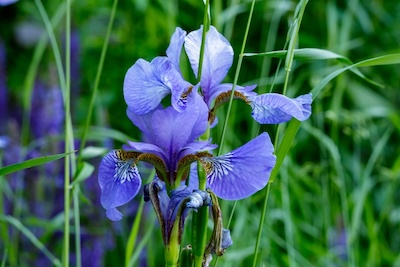

1. Examine the contents and data types of the data set *iris*.

```r
str(iris)
```

```
## 'data.frame':    150 obs. of  5 variables:
##  $ Sepal.Length: num  5.1 4.9 4.7 4.6 5 5.4 4.6 5 4.4 4.9 ...
##  $ Sepal.Width : num  3.5 3 3.2 3.1 3.6 3.9 3.4 3.4 2.9 3.1 ...
##  $ Petal.Length: num  1.4 1.4 1.3 1.5 1.4 1.7 1.4 1.5 1.4 1.5 ...
##  $ Petal.Width : num  0.2 0.2 0.2 0.2 0.2 0.4 0.3 0.2 0.2 0.1 ...
##  $ Species     : Factor w/ 3 levels "setosa","versicolor",..: 1 1 1 1 1 1 1 1 1 1 ...
```

```r
summary(iris)
```

```
##   Sepal.Length    Sepal.Width     Petal.Length    Petal.Width
##  Min.   :4.300   Min.   :2.000   Min.   :1.000   Min.   :0.100
##  1st Qu.:5.100   1st Qu.:2.800   1st Qu.:1.600   1st Qu.:0.300
##  Median :5.800   Median :3.000   Median :4.350   Median :1.300
##  Mean   :5.843   Mean   :3.057   Mean   :3.758   Mean   :1.199
##  3rd Qu.:6.400   3rd Qu.:3.300   3rd Qu.:5.100   3rd Qu.:1.800
##  Max.   :7.900   Max.   :4.400   Max.   :6.900   Max.   :2.500
##        Species
##  setosa    :50
##  versicolor:50
##  virginica :50
##
##
##
```

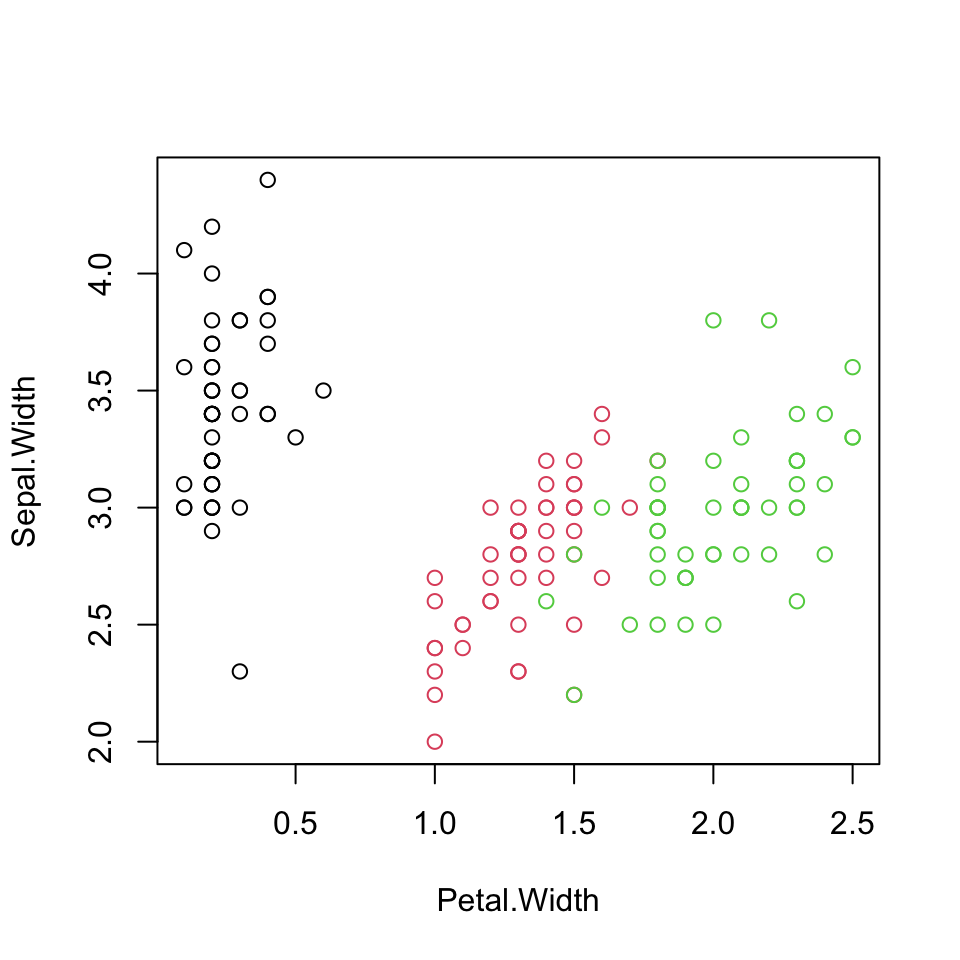

```r
plot(Sepal.Width ~ Petal.Width, iris, col = Species)
```

```r
df0 <- iris[, c('Sepal.Width', 'Petal.Width')]
```

2. Try to find three clusters in the data of sepal and petal widths using a k-means algorithm. You can use the function `kmeans` in R. It allows to choose an algorithm with the argument `algorithm` (e.g. `algorithm = "Forgy"`).

```r
## Number of clusters
n_clust <- 3
## k-means with k = 3 and Forgy's algorithm
km <- kmeans(df0, centers = n_clust, algorithm = "Forgy")
## k-means with k = 3 and Hartigan and Wong's algorithm (as the default)
km <- kmeans(df0, centers = n_clust)
```

3. Plot the data and color by cluster ID

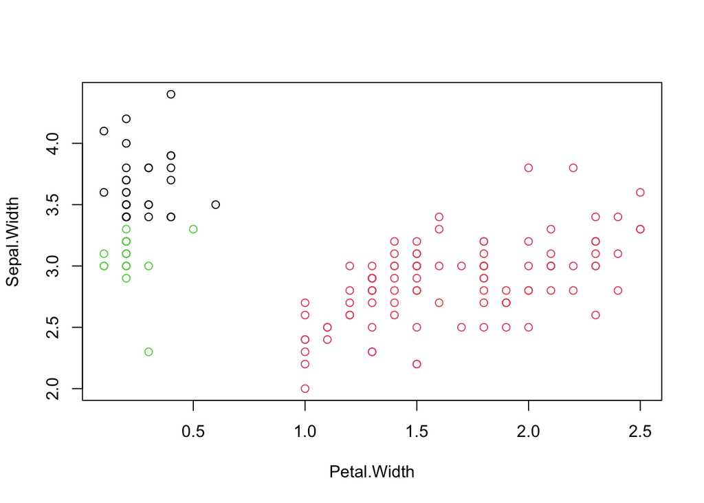

```r
df <- df0
## The cluster identities are stored in km$cluster, same order as input
df$Cluster <- factor(km$cluster)
## Plot using base R graphics
plot(Sepal.Width ~ Petal.Width, df, col = Cluster)
```

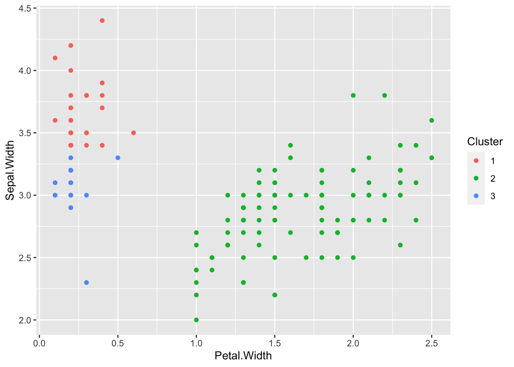

```r
## alternatively, plot using ggplot
ggplot(df, aes(Petal.Width, Sepal.Width, color = Cluster)) +
  geom_point()
```

4. Repeat the same analysis a few times. Do you get the same clusters all the time? Use `table` to check it allowing different cluster numbers.

```r
## the same analysis
km2 <- kmeans(df0, centers = n_clust)
## Compare the results. Note cluster numbers can be changed.
table(km$cluster, km2$cluster)
```

```
##
##       1   2   3
##   1   0  31   0
##   2   0   0 100
##   3  19   0   0
```

```r
## Visualize the difference
if(sum(table(km$cluster, km2$cluster) > 0) != n_clust) { # different
  df2 <- df0
  df2$Cluster <- factor(km2$cluster)
  df$model  <- "1st model"
  df2$model <- "2nd model"
  df3 <- rbind(df, df2)
  ggplot(df3, aes(Petal.Width, Sepal.Width, color = Cluster)) +
    geom_point() +
    facet_grid(~ model)
}
```

5. Try the argument `nstart` out and compare how stable two runs are. By setting the argument to 4, the algorithm will automatically try four different (random) starting points.

```r
km3.1 <- kmeans(df0, centers = n_clust, nstart = 4)
km3.2 <- kmeans(df0, centers = n_clust, nstart = 4)
table(km3.1$cluster, km3.2$cluster)
```

```
##
##      1  2  3
##   1  0  0 49
##   2  0 53  0
##   3 48  0  0
```

6. Try different values for $k$, run the k-means algorithm and collect the WSS (`tot.withinss`). Plot WSS vs $k$. The WSS is always decreasing as $k$ increases, but the curve can still give you a hint of which $k$ to choose. The Elbow method for selecting $k$ is to look at this curve and choose the $k$ that you find at the bend of the curve, at the ‘elbow’. Which $k$ would you pick based on this?

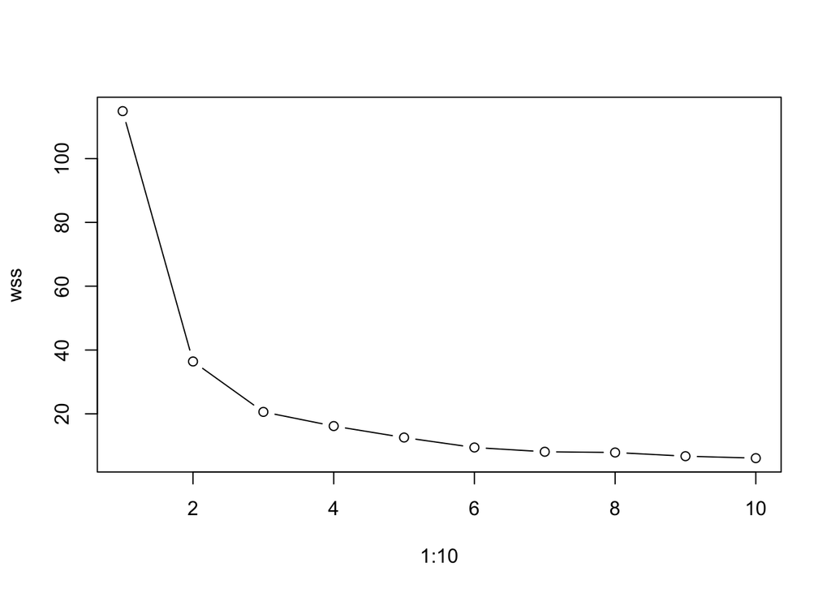

```r
wss <- sapply(1:10, function(k) kmeans(df0, centers = k, nstart = 4)$tot.withinss)
plot(1:10, wss, type = "b")
```

7. Compute the Silhouette width of the first object (or observation) when $k$ is 2.

```r
k <- 2
cl <- kmeans(df0, k)$cluster
## Euclidean distances
d <- sapply(1:nrow(df0), function(ii) sqrt(sum((df0[1, ] - df0[ii, ])^2)))
## a_i = 1 / (|Ca| - 1) * sum(d(i, j))  in the same cluster Ca
ai <- sum(d[cl == cl[1]]) / (sum(cl == cl[1]) - 1)
## other cluster IDs
other_cl <- unique(cl[cl != cl[1]])
## b_i = min( mean(d(i, Cb)) )  average distance to another cluster Cb
bi <- min(sapply(other_cl, function(ocl) mean(d[cl == ocl])))
si <- (bi - ai) / max(ai, bi)
print(si)
```

```
## [1] 0.8001702
```

8. (Optional) Compute average Silhouette width of all objects adjusting $k$ from 2 to 10 and choose optimal $k$. Euclidean distance can be computed by `dist`. Check the help of the function using `?dist`.

```r
n <- nrow(df0)
dm <- as.matrix(dist(df0))   # matrix output for row wise analysis
sil <- sapply(2:10, function(k) {
  cl <- kmeans(df0, k)$cluster
  si <- sapply(1:n, function(ii) {
    ## a_i = 1 / (|Ca| - 1) * sum(d(i, j))  in the same cluster Ca
    ai <- sum(dm[ii, cl == cl[ii]]) / (sum(cl == cl[ii]) - 1)
    ## other cluster IDs
    other_cl <- unique(cl[cl != cl[ii]])
    ## b_i = min( mean(d(i, Cb)) )  average distance to another cluster Cb
    bi <- min(sapply(other_cl, function(ocl) mean(dm[ii, cl == ocl])))
    ## s_i
    (bi - ai) / max(ai, bi)
  })
  mean(si)
})
print(sil)
```

```
## [1] 0.6273425 0.5212381 0.4659839 0.4628995 0.4230378 0.4275813 0.4232549
## [8] 0.4198754 0.3908412
```

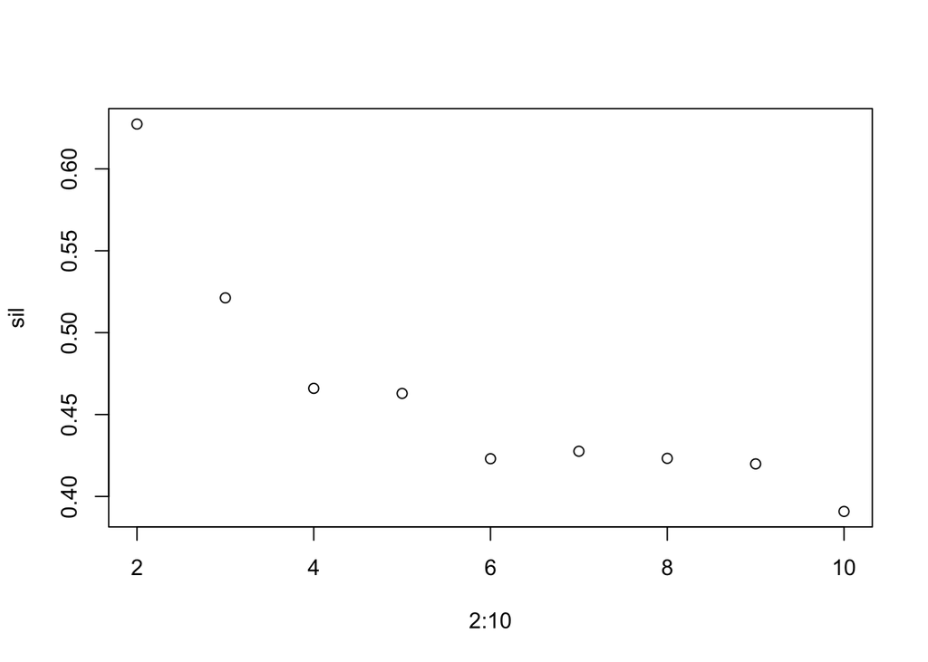

```r
plot(2:10, sil)
```

1. (Optional) Try `fviz_nbclust` of the R-package `factoextra` and choose optimal $k$ based on average Silhouette width.

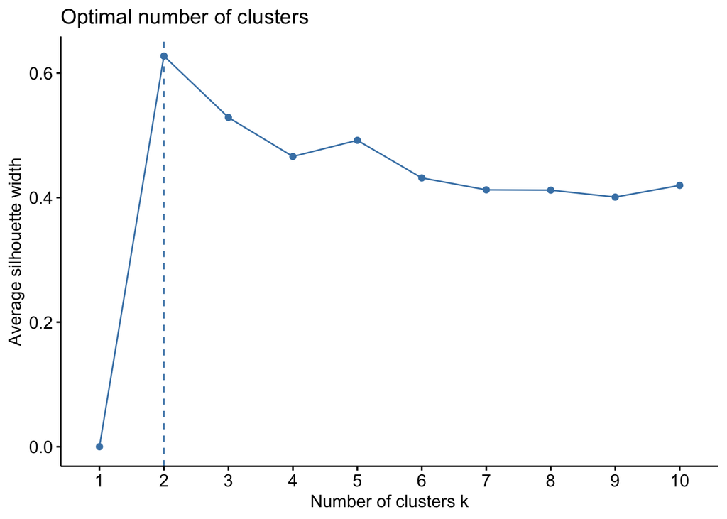

```r
# install.packages("factoextra")  # if the package was not installed before
factoextra::fviz_nbclust(df0, kmeans, method="sil")
```

#### Exercise 2

The NCI60 data set consists of gene expression values for 6830 genes for 64 cell lines. Using this data set, we investigate a few hierarchical clustering distances and linkage methods. The data can be downloaded in R using the following command

```
nci_data <- read.table(
  url("https://web.stanford.edu/~hastie/ElemStatLearn/datasets/nci.data.csv"),
  sep = ",",
  row.names = 1,
  header = TRUE
)
nci_label <- scan(
  url("https://web.stanford.edu/~hastie/ElemStatLearn/datasets/nci.label.txt"),
  what = ""
)
```

1. What is the size of the data matrix? Do every column represent a gene or a cell line?

```r
dim(nci_data)
```

```
## [1] 6830   64
```

```r
nci_data[1:5, 1:5]
```

```
##        s1       s2     s3     s4     s5
## g1  0.300 0.679961  0.940  0.280  0.485
## g2  1.180 1.289961 -0.040 -0.310 -0.465
## g3  0.550 0.169961 -0.170  0.680  0.395
## g4  1.140 0.379961 -0.040 -0.810  0.905
## g5 -0.265 0.464961 -0.605  0.625  0.200
```

```r
## ANS : Rows are genes, and columns are cell lines
```

2. Compute the Euclidean distance **between cell lines**. This can be accomplished using the function `dist`. Read the help text `?dist`. This function computes the distance between rows of the input data matrix. If the rows represent cell lines, you can run `dist(nci_data)`. But, if your cell lines are represented by columns, you need to transpose the data matrix first `t(nci_data)`.

```r
d <- dist(t(nci_data))
```

3. Cluster the cell lines using complete linkage hierarchical clustering, use the function `hclust`.

```r
hc <- hclust(d, method = "complete")   # no need to specify the method
```

4. Plot the dendrogram of the clustering result (The help for `hclust` includes the function for the plot)
   - Try changing the labels to something more informative using `nci_label`.
   - Investigate the argument `hang`, what happens if you set it to -1?

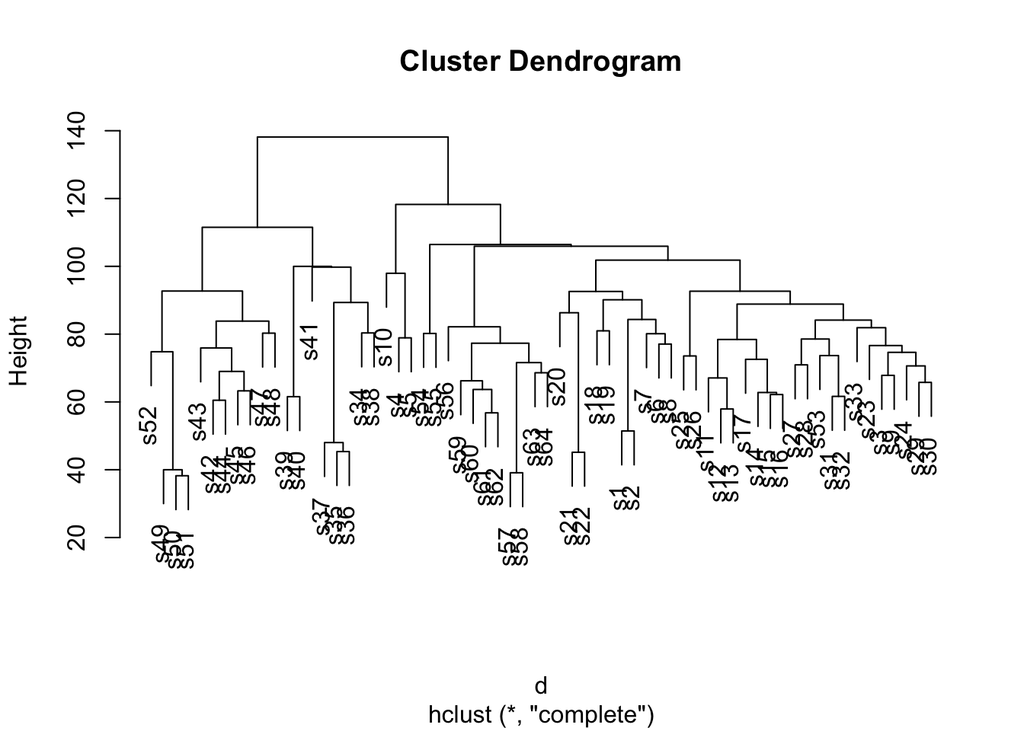

```r
plot(hc)
```

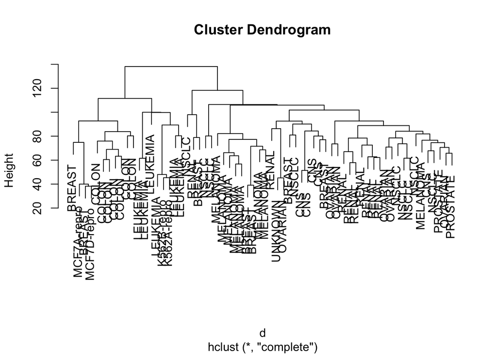

```r
plot(hc, labels = nci_label)
```

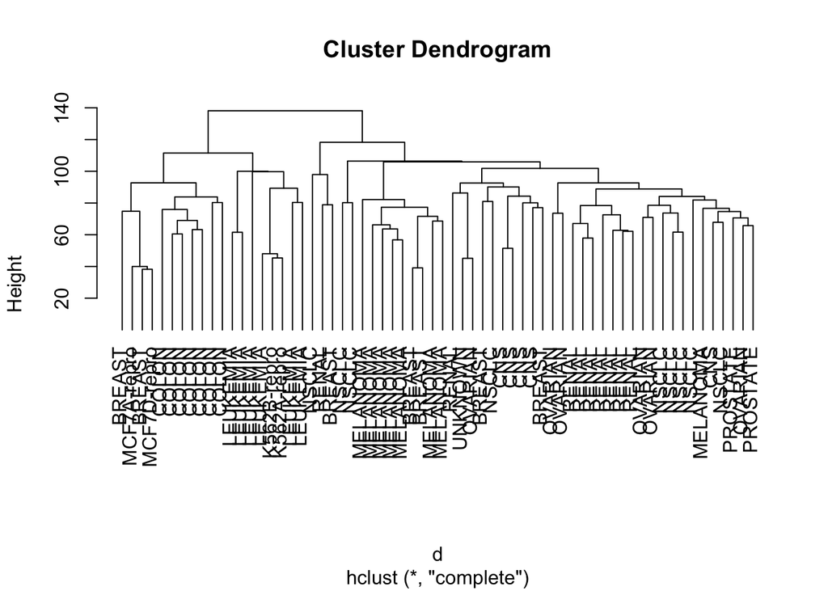

```r
plot(hc, labels = nci_label, hang = -1)
```

5. Try the linkage methods “single”, “average” and “ward.D” in addition to “complete”. Compare the results. Which method is ‘best’?

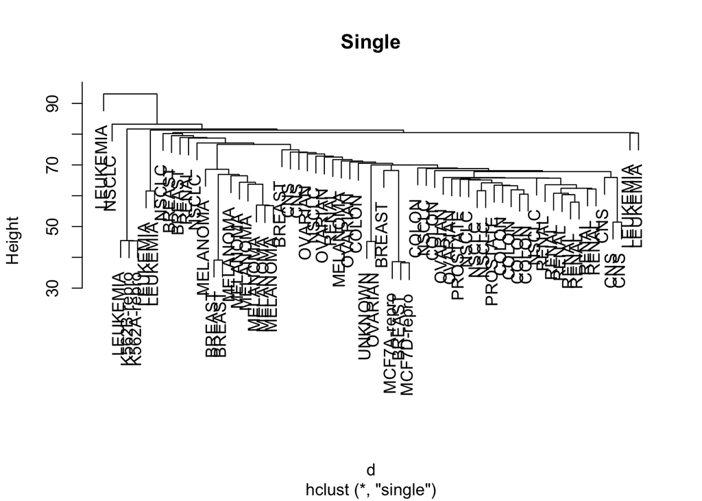

```r
hc_s <- hclust(d, method = "single")
plot(hc_s, labels = nci_label, main = "Single")
```

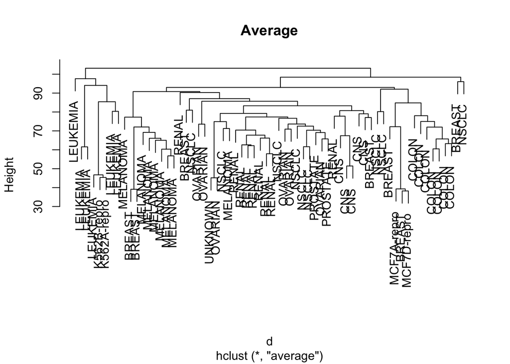

```r
hc_a <- hclust(d, method = "average")
plot(hc_a, labels = nci_label, main = "Average")
```

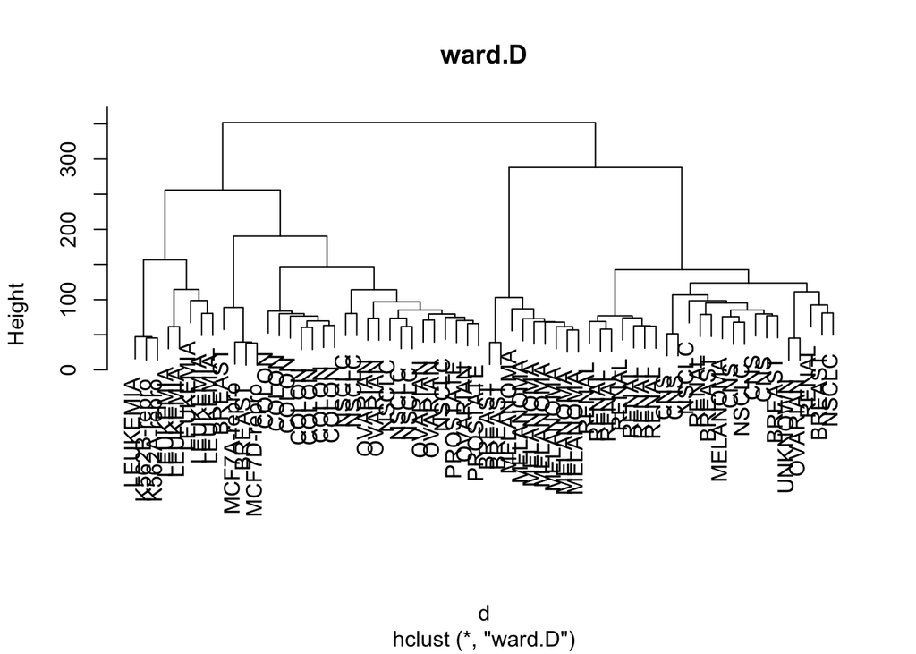

```r
hc_w <- hclust(d, method = "ward.D")
plot(hc_w, labels = nci_label, main = "ward.D")
```

Pick the tree resulting from the method you think is ‘best’. How many clusters are there?

You can cut the tree on any level to get between 1 and 64 clusters. The function `cutree` either on a specific height (dissimilarity) or to get a specific number of clusters.